# Introduction to Resource Selection

Jared Stabach & Majaliwa Masolele, Smithsonian Conservation Biology Institute

10 April 2021

# Introduction

Habitat selection is the process by which animals use certain habitat types/resources. If an animal is located in a habitat type more than would be expected by random, then it is assumed that the animal is selecting for the habitat. In contrast, if an animal uses a particular habitat/resource less than it’s availability, it is assumed that the animal avoids or does not prefer the habitat/resource. Determining habitat use patterns is critical to the effective management and conservation of animals. Global positioning system data allow fine-scale assessments of habitat selection. These data are typically analyzed in a resource selection function (RSF) or step selection function (SSF) framework. In each of these cases, animal *‘use’* locations are contrasted with random locations (the *‘availability’* sample). Differences, however, exist between these two frameworks, which importantly include how much or how little (or at all) the movement process is included. RSF models are point-process models where the movement process is largely ignored, with many arguing that a step selection function more effectively incorporates the movement process. I believe that both frameworks can be used effectively, dependent on your research question and scale of inference.

In the examples that follow, we will integrate the wildebeest dataset that we cleaned in previous exercises, conducting a point-based RSF model to evaluate habitat suitability. This is meant as a first step towards more complex models which incorporate the animal movement process. All of these models, however, are essentially point-process models using logistic regression and are similar to previous lectures using presence/absence data, although we now must generate our ‘pseudo’-absence data because these data do not exist. The key components of this analysis are:

- Some habitats are preferred over other habitats
- **Resource Selection Functions** quantify preference and avoidance
- The general strategy is to compare *‘used’* locations (GPS data, presence locations) with locations that are *‘available’* (pseudo-absence)
  - Incorporate raster layers that are thought *a-priori* to affect space use
  - Generate a random sample of availability
  - Extract raster values at each ‘use’ and ‘available’ location
  - Perform logistic regression
    $$log[p_i/(1-p_i)] = logit(p_i) = \beta_0 + \beta_1x_1 + \beta_2x_2 + ...+ \beta_nx_n$$
    and
    $$p_i = \frac{exp(\beta_0 + \beta_1x_1 + \beta_2x_2 + \beta_3x_3 + ... + \beta_nx_n)}{1+exp(\beta_0 + \beta_1x_1 + \beta_2x_2 + \beta_3x_3 + ... + \beta_nx_n)}$$
    But, for use/availablity designs, we drop the intercept (its meaningless), and focus only on:
    $$w(x,\beta) = exp(\beta_1x_1 + \beta_2x_2 + ...+ \beta_nx_n)$$
  - Positive $\beta$’s indicate preference; Negative $\beta$’s indicate avoidance
  - Generate a map, providing a prediction of habitat use

We’ll be following details provided in the following publications:

Fieberg, J., J. Signer, B. Smith, and T. Avgar. 2021. A ‘How to’ guide for interpreting parameters in habitat‐selection analyses. [Journal of Animal Ecology 00:1-17](https://besjournals.onlinelibrary.wiley.com/doi/10.1111/1365-2656.13441).

Signer, J., J. Fieberg, and T. Avgar. 2019. Animal movement tools (amt): R package for managing tracking data and conducting habitat selection analyses. [Ecology and evolution 9(2): 880-890](https://www.ncbi.nlm.nih.gov/pmc/articles/PMC6362447/).

Stabach, J.A., G. Wittemyer, R.B. Boone, R.S. Reid, J.S. Worden. 2016. Variation in habitat selection by white-bearded wildebeest across different degrees of human disturbance. [Ecosphere 7(8)](https://esajournals.onlinelibrary.wiley.com/doi/full/10.1002/ecs2.1428).

## Load Libraries

```r
# Remove everything from memory
rm(list=ls())

set.seed(533)

# Make sure required libraries are loaded
library(amt)
library(dplyr)
library(ggplot2)
library(jtools)
library(lme4)
library(lubridate)
library(raster)
library(sp)
library(sjPlot)
library(usdm)
library(visreg)

# TimeZone
Timezone1 <- "UTC"
Timezone2 <- "Africa/Nairobi"

# Spatial reference information
LatLong.proj <- "+proj=longlat +ellps=WGS84 +datum=WGS84 +no_defs"  # EPSG:4326
#https://spatialreference.org/ref/esri/102022/
AEA.Africa.proj <- "+proj=aea +lat_1=20 +lat_2=-23 +lat_0=0 +lon_0=25 +x_0=0 +y_0=0 +ellps=WGS84 +datum=WGS84 +units=m +no_defs"   #ESRI:102022
```

## Load Data

Read in the data and transform from Latitude/Longitude to Albers Equal Area. Note, the projection used doesn’t matter too much, as long as you are consistent between the data layers (point and raster) you are using. Use a projection that minimizes the amount of distortion across your study area (return to Ramiro’s lecture for further clarification on projections and spatial transformations). We will only be using the `wild.Athi` object for analyses.

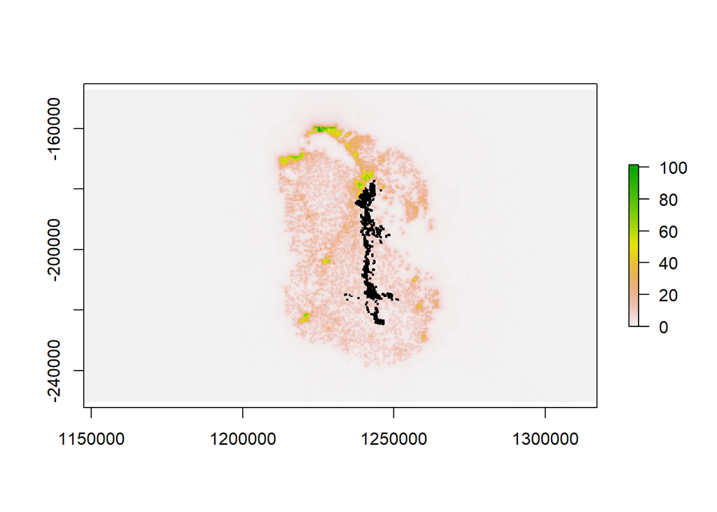

```r
# Read GPS collar data saved as an object in previous exercise
# ******************************
# ******************************
load("./Data/wild.Rdata")

# Read spatial data - Rasters for Athi-Kaputiei Plains
# ******************************
# ******************************
load("./Data/wild_SpatialData.Rdata")

# Stack the rasters together
rsf.stack <- stack(anth_risk,fence_dist,prirds_dist,secrds_dist,river_dist,waterpts_dist,woody_dist)

# All files have been project to Albers Equal Area, with a spatial resolution of 250m
# I have included:
# anth_risk - Anthropogenic Risk, simply an index of human footprint made specifically for this ecosystem (expected negative response)
# Fence_dist - Fence Distance, with fences manually map by a Kenyan field team (expected negative response)
# prirds_dist - Primary Road Distance, the distance from primary/paved roads (expected negative response)
# secrds_dist - Secondary Road Distance, the distance from secondary/unpaved roads (expected null response)
# river_dist - River Distance, the distance from permanent rivers (depending on season, but wildebeest must drink - greater attraction in dry season, but a predation risk)
# waterpts_dist - Water Point Distance, the distance to mapped water wells (expected positive response, stronger in dry season)
# woody_dist -Woody Distance, the distance to woody vegetation (based on VCF) (expected negative response - predation risk)

# Project to Albers Equal Area (maintains distances across study areas and gets around the problem of working across UTM zones)
# DEFINE the projection first
wild.Athi <- SpatialPointsDataFrame(coords = wild.Athi[,c("location.long","location.lat")],
                                    data = wild.Athi,
                                    proj4string = CRS(LatLong.proj))
# Simple plot, to make sure things look correct
#plot(wild.Athi, xlab="Longitude",ylab="Latitude", main = "Athi-Kaputiei Plains Wildebeest Data", axes=T) # Don't need to specify the coordinates because R recognizes the file as spatial.  If the file was a dataframe, we would need to specify the X and Y fields

# Transform to Albers Equal Area Project - Good practice to see a different projection and to see that the code is essential the same.  This projection is good for maintaining areas across regions that span multiple UTM zones.  The parameters from the projection are specific to Africa.
wild.Athi <- spTransform(wild.Athi,
                         CRS =  CRS(AEA.Africa.proj))
#plot(wild.Athi, xlab="Easting",ylab="Northing", main = "Athi-Kaputiei Plains Wildebeest Data", axes=T)

# Plot one of the images in the raster stack with one of the tracking datasets
plot(rsf.stack[[1]])
points(wild.Athi[wild.Athi$id == 30077,], pch = '.', cex = 2, col='black')
```

```r
# Convert to dataframe for statistical analysis
wild.Athi <- as.data.frame(wild.Athi)

# Let's clean up this dataset a bit, keeping only the columns important for this analysis
# wild.Athi <- wild.Athi %>% select(
#   id = id,
#   animal = individual.local.identifier,
#   sex = animal.sex,
#   timestamp = timestamp,
#   easting = location.long.1,
#   northing = location.lat.1
# )

# Select function was giving a hard time...re-arranging/re-selecting as follows
wild.Athi <- wild.Athi[,c(1,11,13,2,15:16)]
colnames(wild.Athi) <- c("id","animal","sex","timestamp","easting","northing")

# In this case, we will not be incorporating time (like you would in a SSF), but could be a vastly important component depending on your research question
# Good to check our formats and make sure the timestamps are in the correct format.
str(wild.Athi)
```

```
## 'data.frame':    100775 obs. of  6 variables:
##  $ id       : int  2840 2840 2840 2840 2840 2840 2840 2840 2840 2840 ...
##  $ animal   : chr  "Sotua" "Sotua" "Sotua" "Sotua" ...
##  $ sex      : chr  "m" "m" "m" "m" ...
##  $ timestamp: POSIXct, format: "2010-10-16 16:00:00" "2010-10-16 17:00:00" ...
##  $ easting  : num  1227064 1227064 1227227 1227242 1227380 ...
##  $ northing : num  -164301 -164302 -164481 -164676 -164955 ...
```

# Fit RSF model

We will use the [amt](https://cran.r-project.org/web/packages/amt/index.html) package to fit a simple, point-based RSF analysis. This is considered a first step in habitat selection analyses. You’ll note many similarities to the occurrence model we fit with Addax, although things can get complicated very quickly. Many different packages exist to execute this type of analysis, each of which has their own set of nuances and nice set of functions. [Amt](https://cran.r-project.org/web/packages/amt/index.html) relies heavily on piping, which has a bit of a (steep) learning curve, but can really help in streamlining the data processing workflow.

A common concern with RSF analyses is that data points are highly correlated in both space and time. This is a legitimate statistical concern, but one that does not have a good resolution using the workflow that we will follow here. As an ad hoc way to try to remove (at least some) of the autocorrelated nature of the movement process, we will thin the movement dataset. This is less than desirable (i.e., you just spent your hard earned money and time to collect these data and likely want to include all the data points you collected). Please regard this analysis as a first step in potential analyses that you will ultimately conduct with your movement data. There is a huge amount of research currently being conducted to address these issues.

## Fitting a Model for a Single Animal

Here will take the first initial steps to fit an RSF to a single individual, providing the framework for a RSF analysis.

```r
# Select a single individual (e.g., 30077)
wb <- wild.Athi[wild.Athi$id==30077,]
#plot(wb$easting,wb$northing, xlab="Easting", ylab="Northing", main=paste0("Animal: ",unique(wb$id)," - Ntishya"), cex=2, pch=".",col="blue",frame=F)

# We've already checked complete cases, already checked timestamp as as.POSIXct, and removed duplicates
# We need to create a track object using mk_track function (this is similar to as.ltraj in adehabitatLT)
# Note, for this analysis, we actually will not be incorporated time (that would be a SSF)
wb <- mk_track(wb, .x = easting, .y = northing,
                .t = timestamp, crs = CRS(AEA.Africa.proj),
                id = id, animal = animal, sex = sex)
```

```
## .t found, creating `track_xyt`.
```

```r
# Add steplengths to object
# Simply calculate the distance moved between steps and adding a new column, called sl (steplength)
# Direction/turning angles can also be easily added using `direction_abs()` command.  Not adding here because not incorporating movement process
wb <- wb %>% mutate(
  sl = step_lengths(.))
summary(wb$sl)
```

```
##     Min.  1st Qu.   Median     Mean  3rd Qu.     Max.     NA's
##     0.00    29.45   104.81   272.56   264.03 13048.05        1
```

```r
# Summarize the distribution of time intervals between successive locations to get a general impression for the sampling rate.
summarize_sampling_rate(wb)
```

```
## # A tibble: 1 x 9
##     min    q1 median  mean    q3   max    sd     n unit
##   <dbl> <dbl>  <dbl> <dbl> <dbl> <dbl> <dbl> <int> <chr>
## 1  0.95     1      1  1.55  2.97    91  1.96 11772 hour
```

```r
# Let's sample to 3 hours, but could do others that are more appropriate (daily?)
# Important to be able to defend 'why' you are doing something
wb <- wb %>% track_resample(rate = hours(3), tolerance = minutes(20))
wb
```

```
## # A tibble: 5,876 x 8
##          x_       y_ t_                     id animal  sex      sl burst_
##  *    <dbl>    <dbl> <dttm>              <int> <chr>   <chr> <dbl>  <dbl>
##  1 1241940. -214144. 2010-10-20 11:00:00 30077 Ntishya f     232.       1
##  2 1241740. -214254. 2010-10-20 14:00:00 30077 Ntishya f     187.       1
##  3 1241750. -214391. 2010-10-20 17:00:00 30077 Ntishya f     176.       1
##  4 1241574. -214347. 2010-10-20 21:01:00 30077 Ntishya f     104.       2
##  5 1241518. -214434. 2010-10-21 00:00:00 30077 Ntishya f     121.       2
##  6 1241621. -214370. 2010-10-21 03:00:00 30077 Ntishya f      95.4      2
##  7 1241716. -214361. 2010-10-21 06:00:00 30077 Ntishya f     156.       2
##  8 1241671. -214269. 2010-10-21 09:00:00 30077 Ntishya f      88.4      2
##  9 1241937. -214142. 2010-10-21 12:00:00 30077 Ntishya f     456.       2
## 10 1241745. -214482. 2010-10-21 15:00:00 30077 Ntishya f       0        2
## # ... with 5,866 more rows
```

```r
summary(wb$sl) # Not that the movement rate now changes....because we are simply connecting the points...so more representative of our fix collection schedule than actual movement (need continuous time model for this)
```

```
##     Min.  1st Qu.   Median     Mean  3rd Qu.     Max.     NA's
##     0.00    50.59   147.12   372.81   386.24 13048.05        1
```

```r
# Ad-hoc thinning of Use locations
# we will randomly sample 20% of the locations to use in modeling.
# Here, I'm not using any spatial statistical tests (acf, Moran's I, Geary's C) to determine if this thinning amount is enough
rcd.amt <- ceiling(nrow(wb)*0.20)
wb <- wb[sample(1:nrow(wb),size = rcd.amt),c("x_","y_","t_")]
#wb # Not that object is a tibble (a dataframe of dataframes)
#plot(wb$easting,wb$northing, xlab="Easting", ylab="Northing", main=paste0("Animal: ",unique(wb$id)," - Ntishya"), cex=2, pch=".",col="blue",frame=F)
```

### Defining Availability

Perhaps the most important aspect of any habitat selection analysis is the assessment of availability. In a RSF, the assumption is that the distribution of available habitat is constant through time and that the animal has equal access to **ALL* areas with a user-defined area at all points in time (Type III Habitat Selection). This assumption may hold true when positions are observed infrequently (the case more commonly when data were collected infrequently from VHF studies), but less so with many modern telemetry studies.

The goal here, however, is to contrast points where an animal was observed, with locations that were potentially available. We will generate available points within the animals’ MCP home range. The [amt](https://cran.r-project.org/web/packages/amt/index.html) function `random_points` is a convenient way to do this, using the [sp](https://cran.r-project.org/web/packages/sp/index.html) command `spsample` to do so.

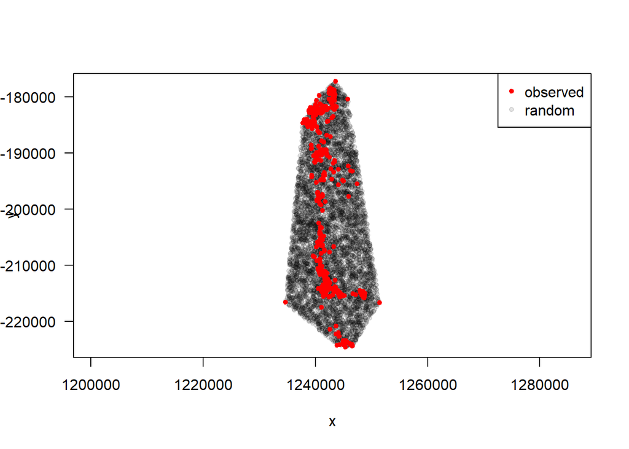

```r
# Lot's of ways to assess availability
# Here we are generating 5 times the number of Use points
wb_RSF<-random_points(wb,n=nrow(wb)*5,typ="random") # Note that this crease a 'case' field (True/False: 1/0)
#unique(wb_RSF$case_)
plot(wb_RSF) # Plot shows Use/Availability
```

```r
# Could also create points in a "regular" pattern....arguably, could be better
#wb2 <- random_points(wb, n=nrow(wb.3hr)*5, typ="regular")
#plot(wb2)

# Extract all the raster variables at all Use/Available points.
# Nice that this is done all with a single command....and very quickly.  Amazing!
# NOTE: we are not considering time here - see extract_covariates_var_time() function to do so, a bit more complicated
wb_RSF <- wb_RSF %>% extract_covariates(rsf.stack)

# Compare values between Use/Available
round(aggregate(wb_RSF[,4:10], by=list(as.numeric(wb_RSF$case_)), FUN=mean),digits=2)
```

```
##   Group.1 anth_risk fence_dist prirds_dist secrds_dist river_dist waterpts_dist
## 1       0      6.86    1244.83     6332.60     1518.91    2200.40       2592.11
## 2       1      6.71     834.06     4001.14     1593.88    2004.19       2197.82
##   woody_dist
## 1   14146.37
## 2   11701.47
```